# Sub Agenda de Áreas Naturales Protegidas

En este blog se presentan los trabajos relacionados con la mesa temática de Áreas Naturales Protegidas.

Héctor A. Lizárraga Cubedo http://ceakumal.org , Gonzalo Merediz Alonso https://www.amigosdesiankaan.org  
04-08-2021

[figure not shown]

# Subagenda Áreas Naturales Protegidas

La subagenda de Áreas Naturales Protegidas es parte de la Agenda Ecológica que Coordina **Héctor A. Lizárraga Cubedo**, director del Centro Ecológico Akumal. El coordinador de esta subagenda es el **M. en C. Gonzalo Merediz Alonso**, quien actualmente es Director de [Amigos de Sian ka ’an](https://www.amigosdesiankaan.org).

Gonzalo tomó posesión como coordinador de la **sub agenda de Áreas Naturales Protegidas** 27 de febrero de 2021 en el Hotel Akumal Bay & Wellness Resort.

## PRIMER TALLER DE ÁREAS NATURALES PROTEGIDAS

[figure not shown]

Figure 1: Primer taller de Áreas Naturales Protegidas de la Agenda Ecológica

- Darío Ferreira;
- Filippo Aureli, Con Mono Maya, A.C.;
- Lucia Diez;
- Xavier Peralta, Contraloría Ciudadana;
- Marco A. Lazcano Barrero, Reserva Ecológica El Edén;
- Gonzalo Merediz Alonso, Amigos de Sian Ka ’an;
- Héctor A. Lizárraga Cubedo, CEA;
- Francisco Hernández, IAPQROO y equipo.

Esta mesa no cuenta con un Secretario Técnico.

Como parte de los Lineamientos para la realización de esta primera etapa se propusieron los siguientes puntos:

1. Un banco de datos e información (mapas, estudios, análisis, hallazgos, encuestas, estadísticas, bases de datos, aplicaciones, normas, planes, programas, presupuestos, proyectos).
2. Descripción de la situación que engloba el tema, respecto al presente.
3. Definición de la problemática que hay que tomar en cuenta en el corto, mediano y largo plazo.
4. Identificación de CAMBIOS urgentes, en los primeros 100 días de gobierno.
5. Definición de proyectos estratégicos.
6. Identificación de actores claves para incidir en el cambio, tanto personales como institucionales.
7. Identificación de fondos privados o públicos para incidir en el tratamiento del tema que se analiza.
8. Identificación de la infraestructura, recursos humanos y financieros que existen para tratar el tema.
9. Identificación y descripción de instrumentos tecnológicos que hay que tomar en cuenta.
10. Definición de cambios en las relaciones de poder entre gobernantes y gobernados, ponderando esquemas de participación ciudadana, transparencia y rendición de cuentas.

### Acuerdos del primer taller (9-mar-21)

Este primer taller trató la importancia de considerar en cualquier programa de trabajo municipal el tema de la Conectividad. Los asistentes resaltaron también la necesidad de bscar esquemas innovadores de políticas públicas para incentivar la creación de nuevas áreas naturales protegidas en el municipio. Sin embargo, se debe de contar con un esquema eficiente de Inspección y Vigilancia para su operación y Manejo. Al respecto Filppo menciona que sí existen esquemas de Co-Manejo donde las comunidades coadyuvan en el manejo de las ANPs, en particular en Otox Ma’x Yetel Koo, la cual tiene varios objetos importantes de conservación. El Co-manejo aunque esta contemplado en la ley no se ha impulsado apropiadamente pero podría ser una muy buena opción. Para ello es importante una mejor comunicación con las comunidades para que conozcan la importancia de las ANPs.

Los Ordenamientos aunque suponen un compromiso entre el gobierno y sociedad no han dimensionado eficientemente el tema de la conectividad, los objetos de conservación y no permiten impulsar el decreto de las ANPs.

El tema de la Reserva hidrogeológica del Norte del Estado que se propuso originalmente en 2008, tal vez no sea un tema a impulsar en el corto plazo, de acuerdo a los presentes, ya que se requiere mayor información sobre los beneficios que este esquema de conservación implica, sobretodo ante la falta de esquemas de financiamiento o incentivos fiscales claros.

## SEGUNDO TALLER DE ÁREAS NATURALES PROTEGIDAS

[figure not shown]

Figure 2: Segundo taller de Áreas Naturales Protegidas de la Agenda Ecológica

El segundo taller de ésta mesa temática se llevó a cabo, de manera presencial y virtual mediante el uso de la plataforma zoom, el día 31 de marzo a las 11:00hs en el Hotel Akumal Bay & Wellness Resort vía zoom. Al taller asisistieron los siguientes actores:

- Pablo Careaga, Tren Maya, sexto tramo;
- Rocío Peralta, Consultora;
- Xavier Peralta, Contraloría Ciudadana;
- Marco. A Lazcano, Reserva Ecológica El Edén;
- Gonzalo Merediz Alonso, Amigos de Sian Ka ’an;
- Héctor A. Lizárraga Cubedo, CEA;
- Francisco Hernández, IAPQROO y equipo.

### Acuerdos del segundo taller (31-mar-21)

En este taller Héctor Lizárraga compartió la información disponible pública sobre las ANPs decretadas en el municipio, de carácter públicas, con información sobre nombre y categoría del ANP, fecha de decreto, superficie, si cuenta con Programa de Manejo, si cuenta con categorías especiales como Sitio Ramsar o Patrimonio de la Humanidad. Y se trató la posibilidad de promover el establecimiento de *Áreas Voluntarias de Conservación Privadas o Ejidales*. ara el municiio este último esquema, con gran potencial, no ha sido impulsado.

También se consultó las **“MEMORIAS DEL TALLER PARA CONSOLIDAR LA RED DE ÁREAS VOLUNTARIAS DE CONSERVACIÓN EN LA PENÍNSULA DE YUCATÁN (https://www.biodiversidad.gob.mx/corredor/pdf/PROFORCO/36-Memoria-Chetumal.pdf”**. En dicho documento se promueve la red de Áreas de Conservación Privadas o Ejidales, resaltando que estos ejercicios han sido posibles en municipios como Othón P. Blanco, José María Morelos y Felipe Carrillo Puerto, en Quintana Roo. En Tulum **NO** existe ningun área de conservación de éste tipo.

Table 1: Información de las ANPs decretadas en el municipio de Tulum

Nombre

Pública.o.Privada.

Categoría

Superficie.total..ha.

Superficie.terrestre..ha.

Superficie.marina..ha.

Plan.de.maneo

Fecha.de.decreto

Director

Contacto

Consejo.Asesor

Fuente.de.consulta

Sitio.Ramsar

Designación.Internacional.Mundial.

Parque Nacional Tulum

Federación

Parque Nacional

664.32

664.32

0.00

No

24/04/81

Biol. Hugo Navarro Solano

Tel: 984 871 24 79  
Mail: gdpnt@conanp.gob.mx

No

https://simec.conanp.gob.mx/ficha.php?anp=81&reg=9

No

Sian Ka’an

Federación

Reserva de la Biosfera

528147.66

375011.87

153135.79

23/01/15

28/01/1986; recategorización: 07/06/2000

Biól. Felipe Ángel Omar Ortíz Moreno

Si

https://simec.conanp.gob.mx/ficha.php?anp=84&reg=9

27/11/03

- Sitio del Patrimonio Mundial
- Reserva de la Biosfera de la UNESCO * Hombre y Biosfera

Arrecifes de Sian ka’an

Federación

Reserva de la Biosfera

34927.16

1361

34927.16

13/06/11

02/02/98

Biól. Felipe Ángel Omar Ortíz Moreno

Si

https://simec.conanp.gob.mx/ficha.php?anp=84&reg=9

27/11/03

- Sitio del Patrimonio Mundial

Reserva de la Biosfera de la UNESCO

Reserva de la Biosfera Caribe Mexicano

Federación

Reserva de la Biosfera

5754055.40

28,489.49

5725465.90

07/12/16

30/11/18

528147.66

No

Incluye los decretos de Xcacel-Xcaceito y Cozumel

Santuario de la Tortuga Marina, Xcacel-Xcacelito

Estatal

Zona Ecológica Sujeta a Conservación

362.00

34.7

327.40

28/04/00

21/02/98

https://qroo.gob.mx/plan-estatal-de-desarrollo-quintana-roo-2016-2022/eje-5-crecimiento-ordenado-con-sustentabilidad

02/02/04

Playa Tortuguera Xcacel-Xcacelito

Área de Refugio para la Protección de Especies Marinas, Bahía de Akumal

Federación

Área de Refugio para la Protección de Especies Acuáticas

1653.00

1653.00

07/03/16

07/03/16

Biól. Felipe Ángel Omar Ortíz Moreno

No

http://www.dof.gob.mx/nota_detalle.php?codigo=5500131&fecha=06/10/2017

Zona de Refugio Pesquero Akumal

Federación

Zona de Refugio Pesquero

1653.00

NA

13/04/15

No

https://www.dof.gob.mx/nota_detalle.php?codigo=5388585&fecha=13/04/2015

NO

Áreas Voluntarias de Conservación Comunitaria y Privada

NA

NA

Propuesta de acción en ANP, posiblemente impulsar algún ANP, sobre todo en conservación del recurso hídrico.

En Punta Allen, Amigos de Sian Ka ’an ha trabajado para que se dote de un sistema solar, proyecto que el Municipio de Tulum debería de liderar, sobretodo en aporte económico y de gestión. Al respecto, se requiere del liderazgo del municipio para sumarse a una estructura de gobernanza, ejemplo de manejo comunitario.

Posiblemente no impulsar la Reserva Hidrogeológica, del Norte del Estado (propuesta original en 2008 de SEMA), como fue originalmente propuesta, y considerar los tiempos.

Platicar mas sobre los incentivos fiscales con el municipio y el congreso del estado. Con la SEMA ver los mecanismos de incentivos fiscales para desarrollar o impuestos u otros mecanismos de recaudación.

Tratar de armar una estrategia de recaudación-incentivos para que la próxima administración la impulse.

Se preguntó a Pablo Careaga sobre la consideración del proyecto sobre la conservación de los ecosistemas. El áreas ambiental del proyeco tiene la información. La sugerencia es contactar a los responsables.

El proyecto del Tren Maya tiene en particular el “Programa de reubicación de árboles de la carretera”, que podría ser considerado dentro de la agenda.

Ser cuidadosos en presentar nuevas propuestas de ANPs sin antes contar con una estrategia definida.

Proponer los esquemas privados de conservación. No hay un programa de largo plazo de incentivo de pagos.

Impulsar la conservación de los valores naturales y los pasos de fauna, considerarlos en la Agenda no solo en el contexto del proyecto del tren Maya.

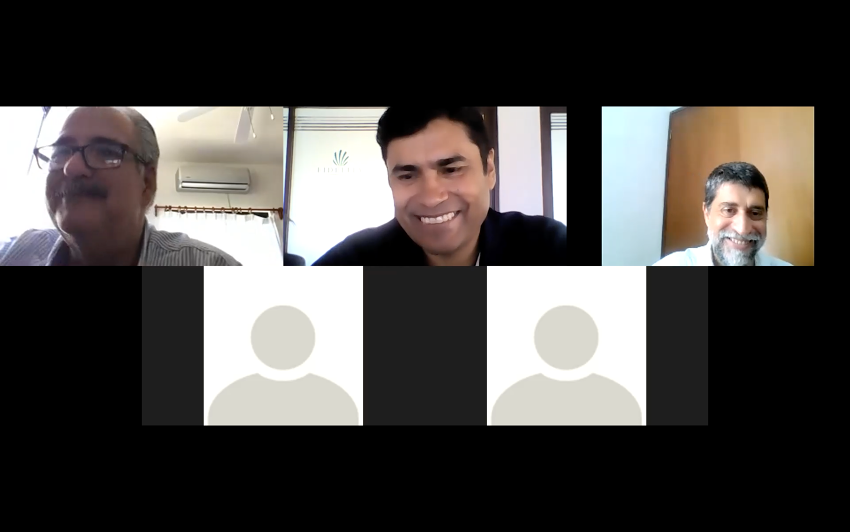

Figure 3: Evidencia del segundo taller de Áreas Naturales Protegidas de la Agenda Ecológica